# Machine Learning Examples

Artificial data set

Stan Mlekodaj

February 29, 2016

## R Packages for Machine Learning

- nnet
- neuralnet
- randomForest
- RSNNS
- deepnet
- H20 (several models including deep learning)
- caret (high level, interfaces with other models)
- rpart (decision trees) Also partykit package for visualization.

## To-Do’s

- Training outputs skewness check
- Feature selection/elimination
  - some models do automatically. i.e. caret
- Feature normalization (caret package?)
- Gradient Checking (usually not possible with off the shelf packages)
- Selecting model complexity (polynomial degree) vs. cross-validation error (caret)
- Selecting lambda (regularization parameter) vs. CV error (caret grid)
- Plotting Learning Curve to detect high bias or variance (mlp in RSNNS)
- Error analysis in CV errors. Trying to categorize CV error sets.
- Determine threshold for output classification
  - Use performance() function to plot measures vs. cutoff.
  - Currently, ROCR supports only binary classification.
  - caret also has tuneGrid input in train()
- F Score, Accuracy, Precision, Recall

## Artificial data set for model testing

Idea: Create input/output data set from a set of equations & random variables. This will create a known model with known correlations & variable importance.

```
##        feat1       feat2      feat3       feat4      feat5 output
## 1  0.2723660  0.02776112  0.6200016  1.55315745 -0.4798723      1
## 2 -0.2795608  1.24322113  1.8150791  0.06300711  0.4666863      1
## 3  0.4198230  0.82035564  2.7301145  0.50779555 -0.1608328      1
## 4  0.2967811 -0.15758305 -0.1156812  0.22573855  0.3169654      0
## 5  1.2200014  0.34964129  1.1538250 -0.88761093  0.5221648      0
## 6  1.0164587  0.41800226 -0.5841328  0.28931483 -1.8316386      1
```

## H2O Package

Installation requires Rcurl, jsonlite & statmod packages required. Need to specify repos if R gives error such as this:

“Package which is only available in source form, and may need compilation of C/C++/Fortran: ‘statmod’”

```
    install.packages("RCurl", repos="http://cran.us.r-project.org")
    install.packages("jsonlite", repos="http://cran.us.r-project.org")
    install.packages("statmod", repos="http://cran.us.r-project.org")
```

install.packages(“h2o”)

or (preferred), download latest version from [link](http://www.h2o.ai/download/)

## General flow

```
1. Define data inputs, ouputs. Make sure outputs are ~50/50 outcomes (not skewed)
    a. Feature selection/elimination, PCA
2. normalize data (except ouputs when binary)
    a. dimensionality reduction/PCA (optional)
3. Split data into training, cross-validation, test sets
4. Train model on training set
5. Tune model parameters for best cross-validation performance
6. Evaluate model on test set
```

## Model Evalulation

ROCR package prediction() & performance(). Can plot metrics vs. cutoff to find best threshold for binary classifier output.

Need to determine what predictor metric is important.

```
1. run model on trainInputs & trainOutputs
2. predict on cvInputs
3. make predict object using prediction(predict, cvOutputs),
4. feed it into performance()
5. choose best "cutoff"
6. report performance metrics for that cutoff
7. predict on testInputs, report performance
```

## Lessons learned

- neural networks
  - SOme literature suggests tanh over logistic function produces better results because it is symmetric around 0.
  - neuralnet() does not take “y ~ .” type of formula. Must write out long formula instead.

## Data Definitions

Input Data Information:

- Number of input features: 5
- Number of outputs: 1
- Number of total data sets: 1000

Training Outputs Skewness:

297, 303

Cross-Validation Outputs Skewness:

100, 100

97, 103

|  | Training Data | Cross-Validation Data | Test Data |
| --- | --- | --- | --- |
| Skewness | 297, 303 | 100, 100 | 97, 103 |
| Data Sets | 600 | 200 | 200 |

## Linear Regression

```
##
## Call:
## lm(formula = fo, data = trainData)
##
## Coefficients:
## (Intercept)        feat1        feat2        feat3        feat4
##     0.51275     -0.01772      0.05926      0.09243      0.19679
##       feat5
##     0.01787
```

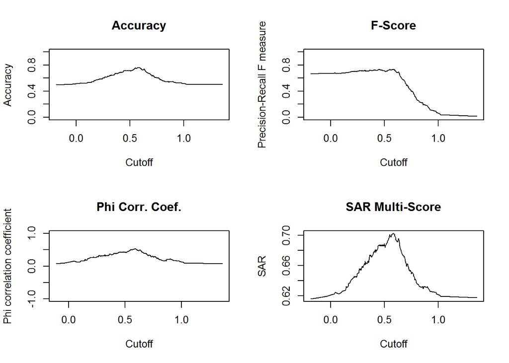

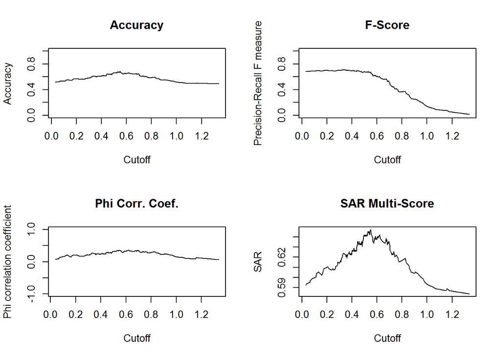

Cross-Validation set Accuracy = 0.76

Test set Accuracy = 0.68

# Generalized Linear Model

```
##
## Call:  glm(formula = fo, family = gaussian(), data = trainData)
##
## Coefficients:
## (Intercept)        feat1        feat2        feat3        feat4
##     0.51275     -0.01772      0.05926      0.09243      0.19679
##       feat5
##     0.01787
##
## Degrees of Freedom: 599 Total (i.e. Null);  594 Residual
## Null Deviance:       150
## Residual Deviance: 117   AIC: 735.7
```

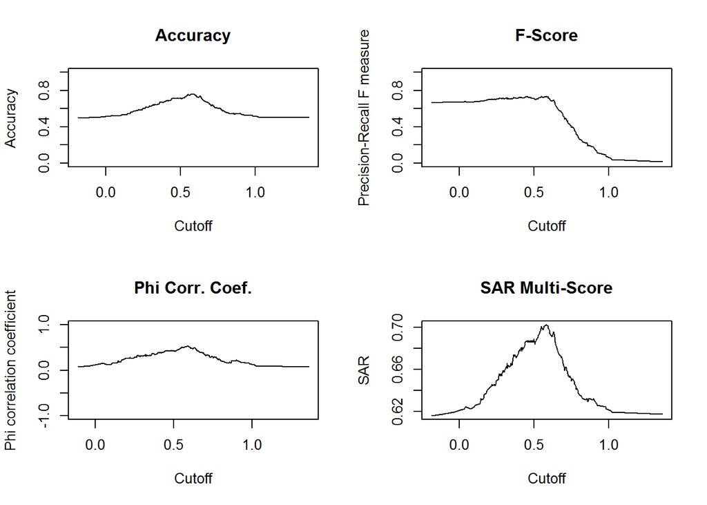

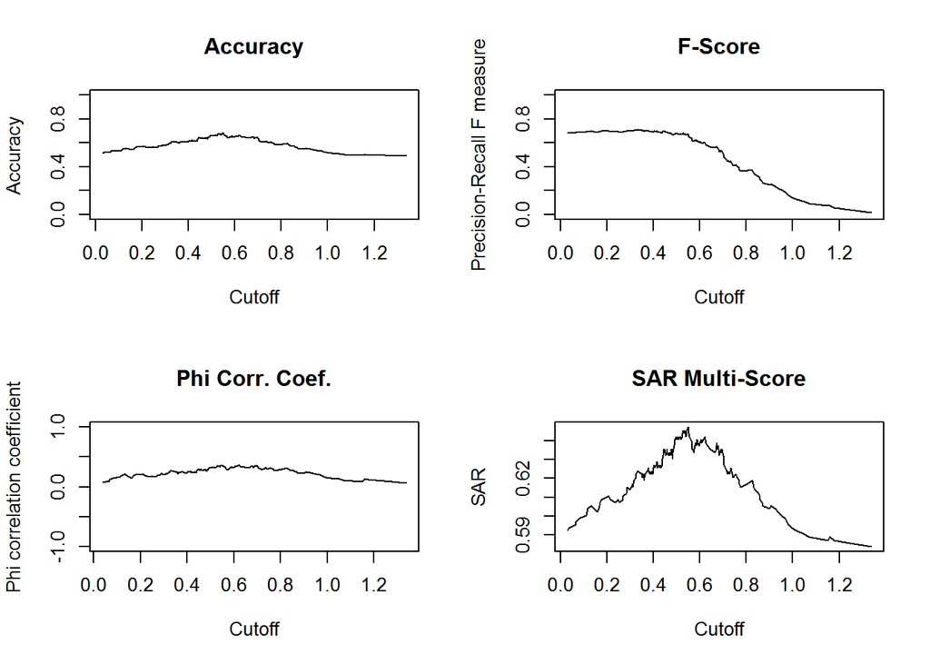

Cross-Validation set Accuracy = 0.76

Test set Accuracy = 0.68

## RSNNS Neural Network - MLP

```
## Class: mlp->rsnns
## Number of inputs: 5
## Number of outputs: 1
## Maximal iterations: 500
## Initialization function: Randomize_Weights
## Initialization function parameters: -0.3 0.3
## Learning function: Quickprop
## Learning function parameters: 0.1 2 1e-04 0.1
## Update function:Topological_Order
## Update function parameters: 0
## Patterns are shuffled internally: TRUE
## Compute error in every iteration: TRUE
## Architecture Parameters:
## $size
## [1] 2
##
## All members of model:
##  [1] "nInputs"               "maxit"
##  [3] "initFunc"              "initFuncParams"
##  [5] "learnFunc"             "learnFuncParams"
##  [7] "updateFunc"            "updateFuncParams"
##  [9] "shufflePatterns"       "computeIterativeError"
## [11] "snnsObject"            "archParams"
## [13] "IterativeFitError"     "IterativeTestError"
## [15] "fitted.values"         "fittedTestValues"
## [17] "nOutputs"
```

```
## SNNS network definition file V1.4-3D
## generated at Wed Mar 02 12:58:14 2016
##
## network name : RSNNS_untitled
## source files :
## no. of units : 8
## no. of connections : 12
## no. of unit types : 0
## no. of site types : 0
##
##
## learning function : Quickprop
## update function   : Topological_Order
##
##
## unit default section :
##
## act      | bias     | st | subnet | layer | act func     | out func
## ---------|----------|----|--------|-------|--------------|-------------
##  0.00000 |  0.00000 | i  |      0 |     1 | Act_Logistic | Out_Identity
## ---------|----------|----|--------|-------|--------------|-------------
##
##
## unit definition section :
##
## no. | typeName | unitName    | act      | bias     | st | position | act func     | out func | sites
## ----|----------|-------------|----------|----------|----|----------|--------------|----------|-------
##   1 |          | Input_feat1 |  1.24964 |  0.16624 | i  | 1,0,0    | Act_Identity |          |
##   2 |          | Input_feat2 | -1.76492 | -0.20572 | i  | 2,0,0    | Act_Identity |          |
##   3 |          | Input_feat3 | -1.62297 |  0.02078 | i  | 3,0,0    | Act_Identity |          |
##   4 |          | Input_feat4 |  0.44672 |  0.19187 | i  | 4,0,0    | Act_Identity |          |
##   5 |          | Input_feat5 | -0.25684 | -0.03697 | i  | 5,0,0    | Act_Identity |          |
##   6 |          | Hidden_2_1  |  0.00000 | -15.33546 | h  | 1,2,0    |||
##   7 |          | Hidden_2_2  |  0.00000 | -24.78116 | h  | 2,2,0    |||
##   8 |          | Output_1    |  0.30281 | -0.83396 | o  | 1,4,0    |||
## ----|----------|-------------|----------|----------|----|----------|--------------|----------|-------
##
##
## connection definition section :
##
## target | site | source:weight
## -------|------|------------------------------------------------------------------------------------------------------------
##      6 |      | 5:1200.41296, 4:14867.08203, 3:8202.61719, 2:5440.12305, 1:-1812.26599
##      7 |      | 5:338.00443, 4:5945.38281, 3:2489.02515, 2:2156.42798, 1:-606.54767
##      8 |      | 7: 0.53151, 6: 1.22175
## -------|------|------------------------------------------------------------------------------------------------------------
```

```
##             Input_feat1 Input_feat2 Input_feat3 Input_feat4 Input_feat5
## Input_feat1           0           0           0           0           0
## Input_feat2           0           0           0           0           0
## Input_feat3           0           0           0           0           0
## Input_feat4           0           0           0           0           0
## Input_feat5           0           0           0           0           0
## Hidden_2_1            0           0           0           0           0
## Hidden_2_2            0           0           0           0           0
## Output_1              0           0           0           0           0
##             Hidden_2_1 Hidden_2_2  Output_1
## Input_feat1  -1812.266  -606.5477 0.0000000
## Input_feat2   5440.123  2156.4280 0.0000000
## Input_feat3   8202.617  2489.0251 0.0000000
## Input_feat4  14867.082  5945.3828 0.0000000
## Input_feat5   1200.413   338.0044 0.0000000
## Hidden_2_1       0.000     0.0000 1.2217474
## Hidden_2_2       0.000     0.0000 0.5315108
## Output_1         0.000     0.0000 0.0000000
```

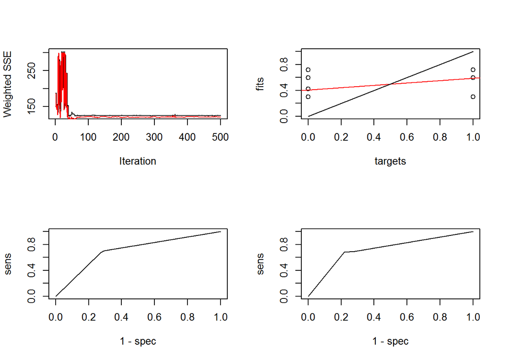

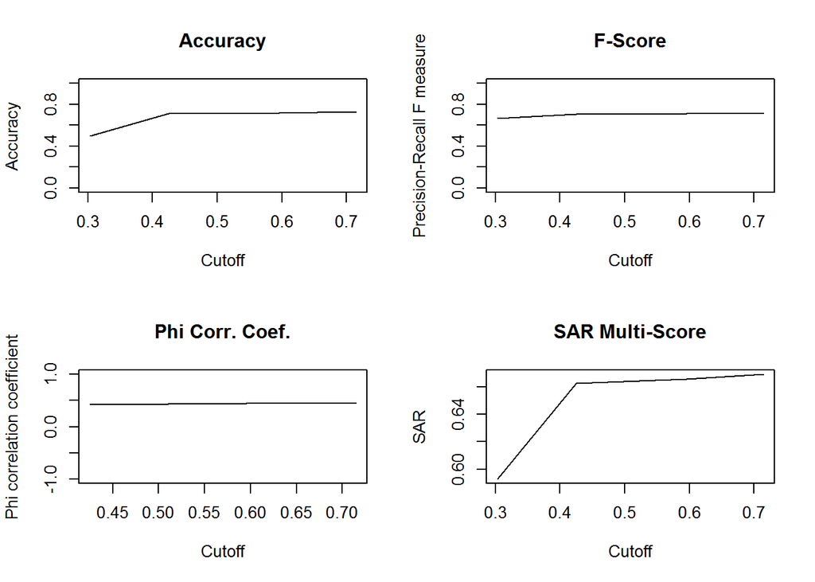

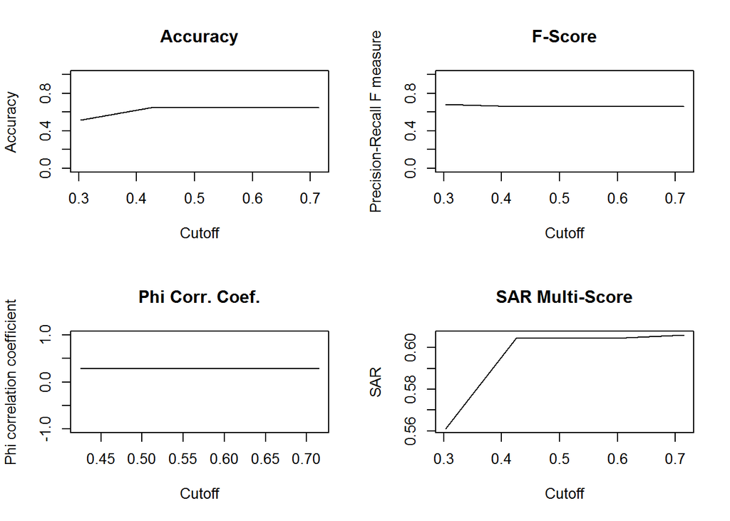

Cross-Validation set Accuracy = 0.73

Test set Accuracy = 0.65

## neuralnet

```
## hidden: 2    thresh: 0.01    rep: 1/1    steps:    1000  min thresh: 0.05067400469
##                                                    2000  min thresh: 0.01791951351
##                                                    3000  min thresh: 0.01025542746
##                                                    3017  error: 331.40363    time: 1.57 secs
```

```
## Call: neuralnet(formula = fo, data = trainData, hidden = 2, threshold = 0.01,     stepmax = 100000, learningrate = 0.01, lifesign = "full",     algorithm = "rprop+", err.fct = "ce", act.fct = "logistic",     linear.output = FALSE)
##
## 1 repetition was calculated.
##
##         Error Reached Threshold Steps
## 1 331.4036301    0.008700811044  3017
```

```
##                     Length Class      Mode
## call                  12   -none-     call
## response             600   -none-     numeric
## covariate           3000   -none-     numeric
## model.list             2   -none-     list
## err.fct                1   -none-     function
## act.fct                1   -none-     function
## linear.output          1   -none-     logical
## data                   6   data.frame list
## net.result             1   -none-     list
## weights                1   -none-     list
## startweights           1   -none-     list
## generalized.weights    1   -none-     list
## result.matrix         18   -none-     numeric
```

Cross-Validation set Accuracy = 0.73

Test set Accuracy = 0.665

## Example from RSNNS R package documentation

```
## SNNS network definition file V1.4-3D
## generated at Wed Mar 02 12:58:17 2016
##
## network name : RSNNS_untitled
## source files :
## no. of units : 12
## no. of connections : 35
## no. of unit types : 0
## no. of site types : 0
##
##
## learning function : Std_Backpropagation
## update function   : Topological_Order
##
##
## unit default section :
##
## act      | bias     | st | subnet | layer | act func     | out func
## ---------|----------|----|--------|-------|--------------|-------------
##  0.00000 |  0.00000 | i  |      0 |     1 | Act_Logistic | Out_Identity
## ---------|----------|----|--------|-------|--------------|-------------
##
##
## unit definition section :
##
## no. | typeName | unitName          | act      | bias     | st | position | act func     | out func | sites
## ----|----------|-------------------|----------|----------|----|----------|--------------|----------|-------
##   1 |          | Input_1           |  0.63091 |  0.06659 | i  | 1,0,0    | Act_Identity |          |
##   2 |          | Input_2           |  0.32031 |  0.23979 | i  | 2,0,0    | Act_Identity |          |
##   3 |          | Input_3           |  0.83786 |  0.08997 | i  | 3,0,0    | Act_Identity |          |
##   4 |          | Input_4           |  1.40823 |  0.22831 | i  | 4,0,0    | Act_Identity |          |
##   5 |          | Hidden_2_1        |  0.06804 | -0.27856 | h  | 1,2,0    |||
##   6 |          | Hidden_2_2        |  0.11038 |  1.30686 | h  | 2,2,0    |||
##   7 |          | Hidden_2_3        |  0.90188 | -0.00110 | h  | 3,2,0    |||
##   8 |          | Hidden_2_4        |  0.99214 |  1.52142 | h  | 4,2,0    |||
##   9 |          | Hidden_2_5        |  0.91289 | -2.65265 | h  | 5,2,0    |||
##  10 |          | Output_setosa     |  0.00381 |  0.41209 | o  | 1,4,0    |||
##  11 |          | Output_versicolor |  0.17290 | -1.37859 | o  | 2,4,0    |||
##  12 |          | Output_virginica  |  0.91077 | -1.60808 | o  | 3,4,0    |||
## ----|----------|-------------------|----------|----------|----|----------|--------------|----------|-------
##
##
## connection definition section :
##
## target | site | source:weight
## -------|------|---------------------------------------------------------------------------------------------------------------------
##      5 |      |  4:-1.25844,  3:-0.98216,  2: 0.84524,  1:-0.02273
##      6 |      |  4:-1.73586,  3:-1.34266,  2: 0.00257,  1: 0.27721
##      7 |      |  4: 1.00086,  3: 1.15896,  2:-0.91276,  1: 0.20812
##      8 |      |  4: 1.33220,  3: 1.60683,  2:-1.55549,  1: 0.93843
##      9 |      |  4: 2.55961,  3: 1.79001,  2:-0.29593,  1:-0.01168
##     10 |      |  9:-1.55364,  8:-2.76536,  7:-2.28685,  6: 1.64496,  5: 0.95151
##     11 |      |  9:-3.45310,  8: 2.69794,  7: 0.32753,  6: 0.73274,  5:-1.28338
##     12 |      |  9: 2.68095,  8: 0.74810,  7: 1.38040,  6:-3.10323,  5:-2.36445
## -------|------|---------------------------------------------------------------------------------------------------------------------
```

```
## Class: mlp->rsnns
## Number of inputs: 4
## Number of outputs: 3
## Maximal iterations: 50
## Initialization function: Randomize_Weights
## Initialization function parameters: -0.3 0.3
## Learning function: Std_Backpropagation
## Learning function parameters: 0.1
## Update function:Topological_Order
## Update function parameters: 0
## Patterns are shuffled internally: TRUE
## Compute error in every iteration: TRUE
## Architecture Parameters:
## $size
## [1] 5
##
## All members of model:
##  [1] "nInputs"               "maxit"
##  [3] "initFunc"              "initFuncParams"
##  [5] "learnFunc"             "learnFuncParams"
##  [7] "updateFunc"            "updateFuncParams"
##  [9] "shufflePatterns"       "computeIterativeError"
## [11] "snnsObject"            "archParams"
## [13] "IterativeFitError"     "IterativeTestError"
## [15] "fitted.values"         "fittedTestValues"
## [17] "nOutputs"
```

```
##                   Input_1 Input_2 Input_3 Input_4     Hidden_2_1
## Input_1                 0       0       0       0 -0.02272668295
## Input_2                 0       0       0       0  0.84524029493
## Input_3                 0       0       0       0 -0.98216295242
## Input_4                 0       0       0       0 -1.25844061375
## Hidden_2_1              0       0       0       0  0.00000000000
## Hidden_2_2              0       0       0       0  0.00000000000
## Hidden_2_3              0       0       0       0  0.00000000000
## Hidden_2_4              0       0       0       0  0.00000000000
## Hidden_2_5              0       0       0       0  0.00000000000
## Output_setosa           0       0       0       0  0.00000000000
## Output_versicolor       0       0       0       0  0.00000000000
## Output_virginica        0       0       0       0  0.00000000000
##                        Hidden_2_2    Hidden_2_3    Hidden_2_4
## Input_1            0.277207612991  0.2081189454  0.9384264946
## Input_2            0.002568511758 -0.9127610922 -1.5554856062
## Input_3           -1.342656850815  1.1589617729  1.6068310738
## Input_4           -1.735861182213  1.0008624792  1.3321986198
## Hidden_2_1         0.000000000000  0.0000000000  0.0000000000
## Hidden_2_2         0.000000000000  0.0000000000  0.0000000000
## Hidden_2_3         0.000000000000  0.0000000000  0.0000000000
## Hidden_2_4         0.000000000000  0.0000000000  0.0000000000
## Hidden_2_5         0.000000000000  0.0000000000  0.0000000000
## Output_setosa      0.000000000000  0.0000000000  0.0000000000
## Output_versicolor  0.000000000000  0.0000000000  0.0000000000
## Output_virginica   0.000000000000  0.0000000000  0.0000000000
##                       Hidden_2_5 Output_setosa Output_versicolor
## Input_1           -0.01167838648  0.0000000000      0.0000000000
## Input_2           -0.29592916369  0.0000000000      0.0000000000
## Input_3            1.79001235962  0.0000000000      0.0000000000
## Input_4            2.55961322784  0.0000000000      0.0000000000
## Hidden_2_1         0.00000000000  0.9515097141     -1.2833845615
## Hidden_2_2         0.00000000000  1.6449592113      0.7327353358
## Hidden_2_3         0.00000000000 -2.2868528366      0.3275279105
## Hidden_2_4         0.00000000000 -2.7653563023      2.6979362965
## Hidden_2_5         0.00000000000 -1.5536375046     -3.4531035423
## Output_setosa      0.00000000000  0.0000000000      0.0000000000
## Output_versicolor  0.00000000000  0.0000000000      0.0000000000
## Output_virginica   0.00000000000  0.0000000000      0.0000000000
##                   Output_virginica
## Input_1               0.0000000000
## Input_2               0.0000000000
## Input_3               0.0000000000
## Input_4               0.0000000000
## Hidden_2_1           -2.3644523621
## Hidden_2_2           -3.1032259464
## Hidden_2_3            1.3803951740
## Hidden_2_4            0.7480999231
## Hidden_2_5            2.6809470654
## Output_setosa         0.0000000000
## Output_versicolor     0.0000000000
## Output_virginica      0.0000000000
```

```
## $infoHeader
##                 name               value
## 1       no. of units                  12
## 2 no. of connections                  35
## 3  no. of unit types                   0
## 4  no. of site types                   0
## 5  learning function Std_Backpropagation
## 6    update function   Topological_Order
##
## $unitDefinitions
##    unitNo          unitName        unitAct        unitBias        type
## 1       1           Input_1 0.630911350250  0.066590487957  UNIT_INPUT
## 2       2           Input_2 0.320306777954  0.239785492420  UNIT_INPUT
## 3       3           Input_3 0.837855756283  0.089967101812  UNIT_INPUT
## 4       4           Input_4 1.408230423927  0.228314995766  UNIT_INPUT
## 5       5        Hidden_2_1 0.068036608398 -0.278560042381 UNIT_HIDDEN
## 6       6        Hidden_2_2 0.110379278660  1.306856393814 UNIT_HIDDEN
## 7       7        Hidden_2_3 0.901883184910 -0.001102484181 UNIT_HIDDEN
## 8       8        Hidden_2_4 0.992136180401  1.521423459053 UNIT_HIDDEN
## 9       9        Hidden_2_5 0.912894010544 -2.652647256851 UNIT_HIDDEN
## 10     10     Output_setosa 0.003811197821  0.412090659142 UNIT_OUTPUT
## 11     11 Output_versicolor 0.172896951437 -1.378589749336 UNIT_OUTPUT
## 12     12  Output_virginica 0.910772800446 -1.608084201813 UNIT_OUTPUT
##    posX posY posZ      actFunc      outFunc sites
## 1     1    0    0 Act_Identity Out_Identity
## 2     2    0    0 Act_Identity Out_Identity
## 3     3    0    0 Act_Identity Out_Identity
## 4     4    0    0 Act_Identity Out_Identity
## 5     1    2    0 Act_Logistic Out_Identity
## 6     2    2    0 Act_Logistic Out_Identity
## 7     3    2    0 Act_Logistic Out_Identity
## 8     4    2    0 Act_Logistic Out_Identity
## 9     5    2    0 Act_Logistic Out_Identity
## 10    1    4    0 Act_Logistic Out_Identity
## 11    2    4    0 Act_Logistic Out_Identity
## 12    3    4    0 Act_Logistic Out_Identity
##
## $fullWeightMatrix
##                   Input_1 Input_2 Input_3 Input_4     Hidden_2_1
## Input_1                 0       0       0       0 -0.02272668295
```

[output cut: 35 more lines]

```
## Output_versicolor  0.00000000000  0.0000000000      0.0000000000
## Output_virginica   0.00000000000  0.0000000000      0.0000000000
##                   Output_virginica
## Input_1               0.0000000000
## Input_2               0.0000000000
## Input_3               0.0000000000
## Input_4               0.0000000000
## Hidden_2_1           -2.3644523621
## Hidden_2_2           -3.1032259464
## Hidden_2_3            1.3803951740
## Hidden_2_4            0.7480999231
## Hidden_2_5            2.6809470654
## Output_setosa         0.0000000000
## Output_versicolor     0.0000000000
## Output_virginica      0.0000000000
```

```
##        predictions
## targets  1  2  3
##       1 44  0  0
##       2  0 36  2
##       3  0  1 44
```

```
##        predictions
## targets  1  2  3
##       1  6  0  0
##       2  0 11  1
##       3  0  0  5
```

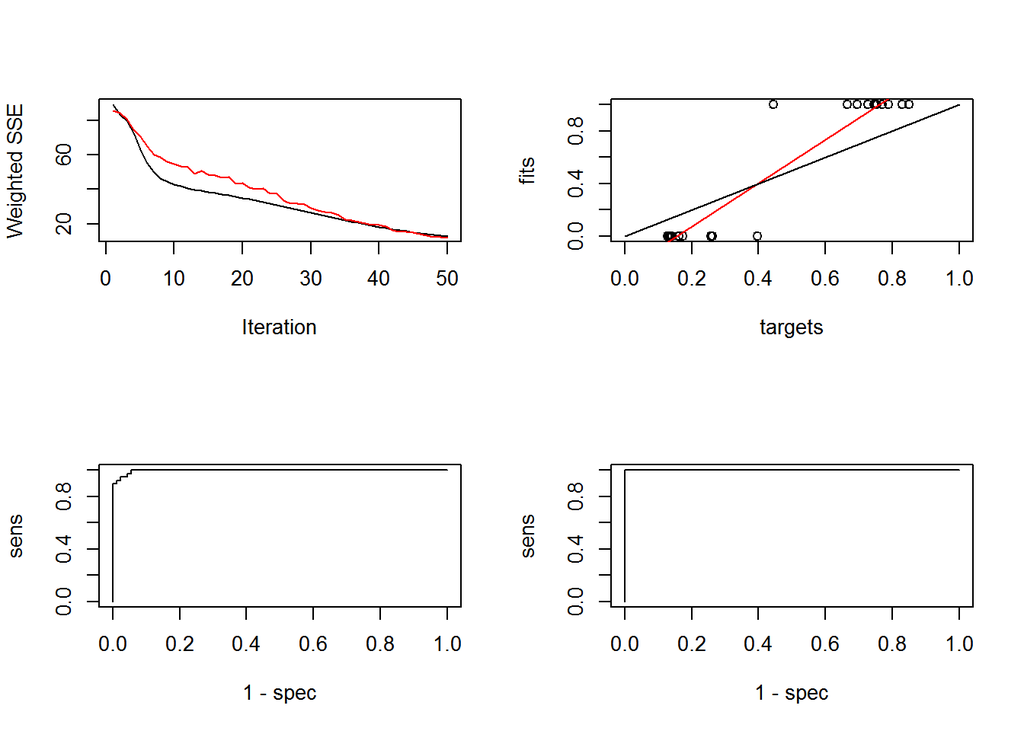

```
##        predictions
## targets  0  1  2  3
##       1  0 44  0  0
##       2  6  0 32  0
##       3  4  0  0 41
```